# Test a Perceptual Phenomenon

### Analyzing the Stroop Effect

Perform the analysis in the space below. Remember to follow [the instructions](https://docs.google.com/document/d/1-OkpZLjG_kX9J6LIQ5IltsqMzVWjh36QpnP2RYpVdPU/pub?embedded=True) and review the [project rubric](https://review.udacity.com/#!/rubrics/71/view) before submitting. Once you've completed the analysis and write up, download this file as a PDF or HTML file and submit in the next section.

(1) What is the independent variable? What is the dependent variable?

- The independet variable is: words condition (ie if the words and ink color is congruent or not)
- The dependent variable is the time taken to answer

(2) What is an appropriate set of hypotheses for this task? What kind of statistical test do you expect to perform? Justify your choices.

$H_{0}$ Null Hypothesis : Answer time is not affected whether the word are congurent or not (population average is independent of word condition) ( μi - μc = 0 )  
$H_{1}$ Alternative Hypothesis: Answer time is dependent on word condition (variation from the population average) ( μi - μc ≠ 0 )  
a dependent t-Test should be used for the following reasons:  
• we are the comparing the means between two related groups on the same continuous, dependent variable  
• The sample size is small (24 inputs) < 30  
• We don't know the population standard deviation  
• The dependent variable is measured on a continous scale  
• The data is almost normally distributed

(3) Report some descriptive statistics regarding this dataset. Include at least one measure of central tendency and at least one measure of variability. The name of the data file is 'stroopdata.csv'.

```python
import pandas as pd
df = pd.read_csv('stroopdata.csv')
df.head()
```

|  | Congruent | Incongruent |
| --- | --- | --- |
| 0 | 12.079 | 19.278 |
| 1 | 16.791 | 18.741 |
| 2 | 9.564 | 21.214 |
| 3 | 8.630 | 15.687 |
| 4 | 14.669 | 22.803 |

```python
df.info()
```

```
<class 'pandas.core.frame.DataFrame'>
RangeIndex: 24 entries, 0 to 23
Data columns (total 2 columns):
Congruent      24 non-null float64
Incongruent    24 non-null float64
dtypes: float64(2)
memory usage: 464.0 bytes
```

```python
#calculating the mean and standard deviation
congurent_mean=df['Congruent'].mean()
Incongurent_mean=df['Incongruent'].mean()
congurent_std=df['Congruent'].std()
Incongurent_std=df['Incongruent'].std()


print(congurent_mean,congurent_std,Incongurent_mean,Incongurent_std )
```

```
14.051125 3.55935795765 22.0159166667 4.79705712247
```

For Congurent Data: The mean = 14.051125 & Standard deviation = 3.55935795765  
For Incongurent Data: The mean = 22.0159166667 & Standard deviation = 4.79705712247

(4) Provide one or two visualizations that show the distribution of the sample data. Write one or two sentences noting what you observe about the plot or plots.

```
Text(0.5,0,'time in seconds')
```

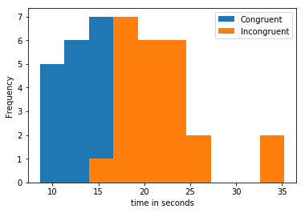

```python
# plottin histograms for the data
%matplotlib inline
import matplotlib.pyplot as plt
df.plot(kind="hist")
plt.xlabel('time in seconds')
```

a quick look on the histograms shows that the time for incongurent condition is more and has a higher mean

(5) Now, perform the statistical test and report the results. What is the confidence level and your critical statistic value? Do you reject the null hypothesis or fail to reject it? Come to a conclusion in terms of the experiment task. Did the results match up with your expectations?

```python
# Perform the statistical test here
import numpy as np
from scipy import stats
t, p = stats.ttest_rel(df['Congruent'],df['Incongruent'])
print("t = " + str(t))
print("p = " + str(p))
```

```
t = -8.02070694411
p = 4.10300058571e-08
```

• Confidence interval is 95%  
• The t-test shows that the congurent instances has an average time less by 8 seconds  
• The very low p-value < 0.05 suggests that we reject the null hypothes and accept that the condition of the words (whether congurent or not affect the response time)  
• The results matched expectations

**References**  
• https://docs.scipy.org/doc/scipy/reference/generated/scipy.stats.ttest_ind.html  
• https://towardsdatascience.com/inferential-statistics-series-t-test-using-numpy-2718f8f9bf2f  
• https://researchrundowns.com/quantitative-methods/significance-testing/